# Modelo Regresión predicción vivienda

## **MODELO DE REGRESIÓN**

```python
#Librerias básicas para manejo de datos y visualización

import numpy as np
import pandas as pd
import seaborn as sns
import warnings
import matplotlib.pyplot as plt

#Librerias de metricas

from sklearn import preprocessing
from sklearn.metrics import mean_absolute_error, mean_absolute_percentage_error,mean_squared_error, r2_score

#Librerias de division del dataset, normalizacion y seleccion de caracteristicas

from sklearn.model_selection import train_test_split
from sklearn.preprocessing import StandardScaler
from mlxtend.feature_selection import SequentialFeatureSelector as SFS

#LIBRERIAS DEL MODELO

from sklearn.linear_model import LinearRegression
from sklearn.model_selection import GridSearchCV
from sklearn.tree import DecisionTreeRegressor
from sklearn.ensemble import RandomForestRegressor

warnings.filterwarnings('ignore')
%matplotlib inline
```

#### **Carga de datos**

En esta primera parte cargaremos los datos y aplicaremos algunas transformaciones para crear el modelo. Se deben realizar los cambios tanto en entrenamiento y validación, como en test, pero nunca llegar a mezclarlos.

##### **`Dataset entrenamiento y validación`**

```python
#Cargamos el dataset de entrenamiento y validación
df = pd.read_csv("df_train_val.csv")
#Creamos una copia del dataset
df_copia = df
#Eliminamos la columna 'id',la columna 'priceByArea y nombre del distrito, ya que no sirve para predicciones
df= df.drop(['priceByArea','district','id'], axis = 1)
```

##### **`Dataset test`**

```python
#Cargamos el dataset de test. Estos serán los datos reales a predecir
df_test = pd.read_csv("df_test.csv")
#Creamos una copia del dataset
df_test_copia = df_test
#Eliminamos la columna 'propertyCode',la columna 'priceByArea y nombre del distrito, ya que no sirve para predicciones
df_test= df_test.drop(['priceByArea','district','propertyCode'], axis = 1)
```

```python
#Para que las columnas esten ordenadas de la misma forma
df_test = df_test[df.columns]
```

#### **Correlación de los datos**

Vamos a analizar la correlacion de las variables predictoras con la variable objetivo `price`.

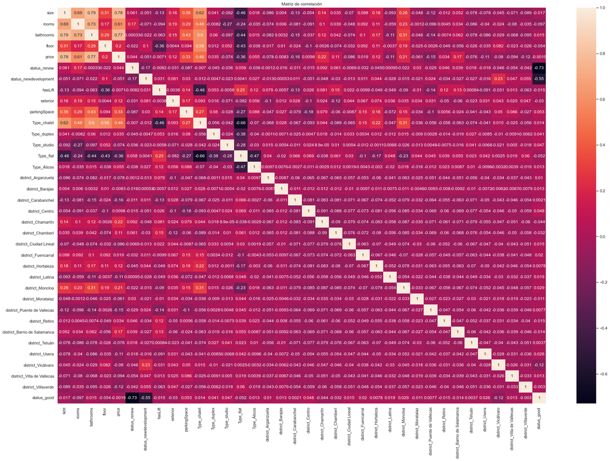

```python
#Establecemos las dimensiones del mapa de calor
sns.set(rc = {'figure.figsize':(30,20)})
#Creamos la matriz de correlación
corr_matrix = df.corr()
#Representamos la matriz de correlacion en mapa de calor
sns.heatmap(corr_matrix, annot = True)
plt.title('Matriz de correlación')
plt.show()
```

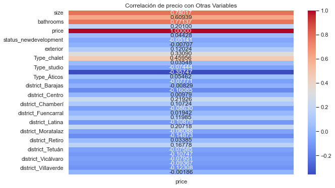

```python
#Represetanmos otra matriz de correlación con el precio para mayor claridad
corr_matrix_price = df.corr()
correlation_with_variable_1 = corr_matrix_price['price']

# Crear un mapa de calor de la correlación de
plt.figure(figsize=(10, 6))
sns.heatmap(correlation_with_variable_1.to_frame(), annot=True, cmap='coolwarm', fmt='.5f')
plt.title('Correlación de precio con Otras Variables')
plt.show()
```

```python
#Filtra las correlaciones que superen abs(0.10)
correlaciones = df.corr()['price']
correlaciones_filtradas = correlaciones[abs(correlaciones) > 0.10]
print(correlaciones_filtradas)
variables_filtradas = correlaciones_filtradas.index.tolist()
```

```
size                            0.780170
rooms                           0.609387
bathrooms                       0.771370
floor                           0.201003
price                           1.000000
exterior                        0.120244
parkingSpace                    0.330900
Type_chalet                     0.459561
Type_flat                      -0.357470
district_Carabanchel           -0.160847
district_Chamartín              0.219259
district_Chamberí               0.107243
district_Hortaleza              0.119849
district_Latina                -0.108791
district_Moncloa                0.207176
district_Puente de Vallecas    -0.148725
district_Barrio de Salamanca    0.167778
district_Usera                 -0.107468
district_Villaverde            -0.123076
Name: price, dtype: float64
```

```python
df_filtradas = df[variables_filtradas]
df_filtradas.head(3)
```

|  | size | rooms | bathrooms | floor | price | exterior | parkingSpace | Type_chalet | Type_flat | district_Carabanchel | district_Chamartín | district_Chamberí | district_Hortaleza | district_Latina | district_Moncloa | district_Puente de Vallecas | district_Barrio de Salamanca | district_Usera | district_Villaverde |
| --- | --- | --- | --- | --- | --- | --- | --- | --- | --- | --- | --- | --- | --- | --- | --- | --- | --- | --- | --- |
| 0 | 72.0 | 2 | 2 | 28 | 424000 | 1 | 1 | 0 | 1 | 0 | 0 | 0 | 0 | 0 | 0 | 0 | 0 | 0 | 0 |
| 1 | 289.0 | 4 | 3 | 28 | 695000 | 1 | 1 | 1 | 0 | 0 | 0 | 0 | 0 | 0 | 0 | 0 | 0 | 0 | 0 |
| 2 | 175.0 | 4 | 2 | 26 | 680000 | 1 | 1 | 0 | 1 | 0 | 0 | 0 | 0 | 0 | 0 | 0 | 0 | 0 | 0 |

#### **MODELOS**

Aplicaremos varios modelos para determinar con cual obtenemos un mejor resultado, empezaremos con una regresión múltiple que nos servirá de referencia

Separaremos la variable objetivo del resto de variable.

```python
#Declara X e y
X = df_filtradas.drop("price", axis = 1)
y = df_filtradas["price"].values
```

Además dividiremos el dataset en entrenamiento (80%) y validación (20%)

```python
#Divide en entrenamiento (80%) y validacion (20%). También muestra el tamaño del cada en valores absolutos
X_train, X_val,y_train, y_val = train_test_split(X, y, test_size = 0.20, random_state = 0)
print(X_train.shape, X_val.shape, y_train.shape, y_val.shape)
```

```
(17250, 18) (4313, 18) (17250,) (4313,)
```

Escalamos los datos

```python
#Escala los datos
scaler = StandardScaler()
X_train = scaler.fit_transform(X_train)
X_val = scaler.transform(X_val)
```

Ahora construiremos una función para obtener las métricas.

```python
def metricas_train_val(y_train, y_train_predict,y_val, y_val_predict):
    '''
    y_train: variable a predecir en entrenamiento
    y_train_predict : variable predicha en entrenamiento
    y_val : variable a predecir en validación
    y_val_predict: variable predicha en validación

    Hace uso de la función 'metricas' para los valores reales y predichos
    de validación y entrenamiento

    '''
    def metricas(y, y_pred,train_val):

        '''
        y: variable a predecir
        y_pred : variable predicha
        train_val: caracter para decidir si es entrenamiento o validación


        Hace uso de la función 'metricas' para los valores reales y predichos
        de validación y entrenamiento

        '''
        # MAE train
        mae = mean_absolute_error(y, y_pred)
        # R2 train
        r2 = r2_score(y, y_pred)
        # MAPE train
        mape= mean_absolute_percentage_error(y, y_pred)
        # MSE train
        mse = mean_squared_error(y, y_pred)
        # RMSE train
        rmse = mean_squared_error(y, y_pred, squared=False)

        metrics = {
            "": [train_val],
            "rmse": [rmse],
            "mse": [mse],
            "r2": [r2],
            "mae": [mae],
            "mape": [mape]
        }
        metrics_df = pd.DataFrame(metrics)

        return metrics_df

    metricas_train = metricas(y_train, y_train_predict,'Train')
    metricas_test = metricas(y_val, y_val_predict,'Val')
    metric = pd.concat([metricas_train, metricas_test], ignore_index=True)

    return metric
```

#### `Regresión Lineal Multiple`

Primero vamos a hacer regresión lineal múltiple con todas las variables seleccionadas para obtener un marco de referencia

```python
#Declara la regresión y la entrena
regression = LinearRegression()
regression.fit(X_train, y_train)
```

```
LinearRegression()
```

```python
y_train_predict = regression.predict(X_train)
y_val_predict = regression.predict(X_val)
```

```python
metricas_regresion = metricas_train_val(y_train, y_train_predict,y_val, y_val_predict)
metricas_regresion
```

|  |  | rmse | mse | r2 | mae | mape |
| --- | --- | --- | --- | --- | --- | --- |
| 0 | Train | 415605.824443 | 1.727282e+11 | 0.714088 | 219429.915417 | 0.419841 |
| 1 | Val | 435220.642484 | 1.894170e+11 | 0.712606 | 225014.147161 | 0.414639 |

Después de evaluar un primer modelo, vamos a hacer otro con la mejor selección de variables en test

```python
# Transforma X_train y val en dataframes, entrena varios modelos con diferentes variables y mide varias métricas
X_train_df = pd.DataFrame(X_train, columns=X.columns)
X_test_df = pd.DataFrame(X_val, columns=X.columns)
dataset_seleccion = pd.DataFrame()

for i in range(1, len(X_train_df.columns)):
    sbs = SFS(LinearRegression(), k_features=i, forward=False, floating=False)
    sbs.fit(np.array(X_train), y_train)
    sbs.k_feature_names_
    regression = LinearRegression()
    selected_features = [X_train_df.columns[int(index)] for index in list(sbs.k_feature_idx_)]
    regression.fit(X_train_df[selected_features], y_train)
    y_pred = regression.predict(X_test_df[selected_features])

    # Calcular métricas
    mse = mean_squared_error(y_test, y_pred)
    rmse = np.sqrt(mse)
    r2 = r2_score(y_test, y_pred)
    mae = mean_absolute_error(y_test, y_pred)
    y_test = np.array(y_test)
    mape = np.mean(np.abs((y_test - y_pred) / y_test)) * 100

    # Crear un DataFrame con las métricas
    metrics = {
        "variables": [selected_features],
        "rmse": [rmse],
        "mse": [mse],
        "r2": [r2],
        "mae": [mae],
        "mape": [mape]
    }
    metrics_df = pd.DataFrame(metrics)

    # Concatenar al dataset_seleccion
    dataset_seleccion = pd.concat([dataset_seleccion, metrics_df], ignore_index=True)
```

```python
#Ordena el modelo de menor a mayor rmse dependiendo de las variables en train
dataset_seleccion.sort_values("rmse")
```

|  | variables | rmse | mse | r2 | mae | mape |
| --- | --- | --- | --- | --- | --- | --- |
| 16 | [size, bathrooms, floor, exterior, parkingSpac... | 435251.354153 | 1.894437e+11 | 0.712566 | 224929.319934 | 41.430300 |
| 15 | [size, bathrooms, floor, exterior, parkingSpac... | 435252.867913 | 1.894451e+11 | 0.712564 | 224932.889868 | 41.416107 |
| 11 | [size, bathrooms, floor, Type_chalet, Type_fla... | 435621.242451 | 1.897659e+11 | 0.712077 | 225166.537173 | 41.349050 |
| 12 | [size, bathrooms, floor, Type_chalet, Type_fla... | 435622.971772 | 1.897674e+11 | 0.712075 | 225173.654054 | 41.464765 |
| 9 | [size, bathrooms, Type_chalet, district_Caraba... | 435688.378489 | 1.898244e+11 | 0.711988 | 224879.060982 | 40.940598 |
| 14 | [size, bathrooms, floor, exterior, Type_chalet... | 435728.644520 | 1.898595e+11 | 0.711935 | 226038.866287 | 41.918246 |
| 13 | [size, bathrooms, floor, Type_chalet, Type_fla... | 435743.492115 | 1.898724e+11 | 0.711915 | 225815.313824 | 41.769567 |
| 10 | [size, bathrooms, floor, Type_chalet, district... | 435882.397831 | 1.899935e+11 | 0.711732 | 225139.053958 | 41.142824 |
| 8 | [size, bathrooms, Type_chalet, district_Caraba... | 435883.933448 | 1.899948e+11 | 0.711730 | 225090.691469 | 40.625046 |
| 7 | [size, bathrooms, Type_chalet, district_Chamar... | 436100.475854 | 1.901836e+11 | 0.711443 | 225355.869309 | 40.282444 |
| 6 | [size, bathrooms, Type_chalet, district_Chamar... | 436402.145841 | 1.904468e+11 | 0.711044 | 225810.187431 | 40.260225 |
| 5 | [size, bathrooms, Type_chalet, district_Chamar... | 436833.176271 | 1.908232e+11 | 0.710473 | 226455.495146 | 40.030580 |
| 4 | [size, bathrooms, district_Chamartín, district... | 437951.433962 | 1.918015e+11 | 0.708989 | 227777.570216 | 39.471080 |
| 3 | [size, bathrooms, district_Chamartín, district... | 444385.693266 | 1.974786e+11 | 0.700375 | 233997.400314 | 40.610757 |
| 2 | [size, bathrooms, district_Barrio de Salamanca] | 453888.479254 | 2.060148e+11 | 0.687423 | 236906.105800 | 41.856567 |
| 1 | [size, bathrooms] | 463708.657432 | 2.150257e+11 | 0.673751 | 242091.395736 | 43.444273 |
| 0 | [size] | 513362.814180 | 2.635414e+11 | 0.600141 | 254558.006897 | 51.655746 |

#### `Árbol de regresión`

Para el árbol de decisión vamos a hacerlo con todas las variables seleccionada primero, luego con un gridSearch y finalmente con una selección de variables

```python
#Declara el árbol de regresión y lo entrena
regression_tree = DecisionTreeRegressor(max_depth = 3, random_state = 0,min_samples_leaf= 2, min_samples_split = 2 )
regression_tree.fit(X_train,y_train)
```

```
DecisionTreeRegressor(max_depth=3, min_samples_leaf=2, random_state=0)
```

```python
y_train_predict = regression_tree.predict(X_train)
y_val_predict = regression_tree.predict(X_val)
```

```python
metricas_arbol = metricas_train_val(y_train, y_train_predict,y_val, y_val_predict)
metricas_arbol
```

|  |  | rmse | mse | r2 | mae | mape |
| --- | --- | --- | --- | --- | --- | --- |
| 0 | Train | 423533.477480 | 1.793806e+11 | 0.703077 | 240902.959858 | 0.534251 |
| 1 | Val | 450056.825186 | 2.025511e+11 | 0.692679 | 246003.591106 | 0.515599 |

Ahora aplicaremos un gridSearch

```python
parameters = {'min_samples_split': [10, 20, 40, 60, 80],
                  'min_samples_leaf': [5, 10, 15, 20,25],
                  'max_depth': [4, 6, 8, 10,12,14,16]
                 }
```

```python
grid_tree = GridSearchCV(estimator=regression_tree, param_grid = parameters)
```

```python
grid_tree.fit(X_train, y_train)
```

```
GridSearchCV(estimator=DecisionTreeRegressor(max_depth=3, min_samples_leaf=2,
                                             random_state=0),
             param_grid={'max_depth': [4, 6, 8, 10, 12, 14, 16],
                         'min_samples_leaf': [5, 10, 15, 20, 25],
                         'min_samples_split': [10, 20, 40, 60, 80]})
```

```python
print("Mejores parámetros del gridSearch:\n",grid_tree.best_params_)
```

```
Mejores parámetros del gridSearch:
 {'max_depth': 16, 'min_samples_leaf': 5, 'min_samples_split': 20}
```

```python
y_train_predict = grid_tree.predict(X_train)
y_val_predict = grid_tree.predict(X_val)
```

```python
metricas_grid_arbol = metricas_train_val(y_train, y_train_predict,y_val, y_val_predict)
metricas_grid_arbol
```

|  |  | rmse | mse | r2 | mae | mape |
| --- | --- | --- | --- | --- | --- | --- |
| 0 | Train | 255361.994568 | 6.520975e+10 | 0.892060 | 125614.569268 | 0.219026 |
| 1 | Val | 324351.457048 | 1.052039e+11 | 0.840379 | 153336.430502 | 0.250268 |

Ahora probaremos con una selección de variables en test

```python
dataset_seleccion = pd.DataFrame()
for i in range(1, len(X_train_df.columns)):
    sbs = SFS(DecisionTreeRegressor(random_state=0), k_features=i, forward=False, floating=False)
    sbs.fit(np.array(X_train), y_train)
    regression = DecisionTreeRegressor(random_state=0)
    regression.fit(X_train_df[[X_train_df.columns[int(index)] for index in list(sbs.k_feature_idx_)]], y_train)
    y_pred = regression.predict(X_test_df[[X_train_df.columns[int(index)] for index in list(sbs.k_feature_idx_)]])

    rmse = np.sqrt(mean_squared_error(y_test, y_pred))
    mae = mean_absolute_error(y_test, y_pred)
    mse = mean_squared_error(y_test, y_pred)
    r2 = r2_score(y_test, y_pred)

    # Calcular el MAPE
    mape = np.mean(np.abs((y_test - y_pred) / y_test)) * 100

    # Crear un DataFrame con todas las métricas
    metrics = {
        "variables": [[X_train_df.columns[int(index)] for index in list(sbs.k_feature_idx_)]],
        "rmse": [rmse],
        "mae": [mae],
        "mse": [mse],
        "r2": [r2],
        "mape": [mape]
    }
    metrics_df = pd.DataFrame(metrics)

    # Concatenar al dataset_seleccion
    dataset_seleccion = pd.concat([dataset_seleccion, metrics_df], ignore_index=True)
```

```python
dataset_seleccion.sort_values(by = "rmse", ignore_index = True)
```

|  | variables | rmse | mae | mse | r2 | mape |
| --- | --- | --- | --- | --- | --- | --- |
| 0 | [size, bathrooms, floor, exterior, parkingSpac... | 344943.974317 | 162014.914716 | 1.189863e+11 | 0.819468 | 28.257298 |
| 1 | [size, floor, Type_flat, district_Chamartín, d... | 349469.481486 | 165535.117417 | 1.221289e+11 | 0.814699 | 30.555519 |
| 2 | [size, floor, Type_flat, district_Chamartín, d... | 351891.591438 | 170564.566965 | 1.238277e+11 | 0.812122 | 32.958314 |
| 3 | [size, floor, Type_flat, district_Chamartín, d... | 352516.150611 | 165716.159101 | 1.242676e+11 | 0.811454 | 30.658562 |
| 4 | [size, floor, Type_flat, district_Chamartín, d... | 353760.204354 | 170350.439257 | 1.251463e+11 | 0.810121 | 32.333225 |
| 5 | [size, floor, exterior, Type_chalet, Type_flat... | 354521.776448 | 163634.809128 | 1.256857e+11 | 0.809303 | 28.887283 |
| 6 | [size, bathrooms, floor, exterior, parkingSpac... | 359839.536708 | 163144.517915 | 1.294845e+11 | 0.803539 | 27.028169 |
| 7 | [size, floor, exterior, Type_flat, district_Ch... | 361298.971348 | 166519.822747 | 1.305369e+11 | 0.801942 | 30.562587 |
| 8 | [size, floor, exterior, Type_flat, district_Ca... | 362222.623341 | 164374.350665 | 1.312052e+11 | 0.800928 | 29.061614 |
| 9 | [size, bathrooms, floor, exterior, parkingSpac... | 367782.314919 | 166157.323851 | 1.352638e+11 | 0.794770 | 28.312360 |
| 10 | [size, floor, Type_flat, district_Chamartín, d... | 372298.029077 | 175781.744289 | 1.386058e+11 | 0.789700 | 33.352595 |
| 11 | [size, bathrooms, floor, exterior, Type_chalet... | 374409.498892 | 166719.730760 | 1.401825e+11 | 0.787308 | 28.878434 |
| 12 | [size, Type_flat, district_Chamartín, district... | 388924.231898 | 184672.828354 | 1.512621e+11 | 0.770497 | 35.347612 |
| 13 | [size, Type_flat, district_Chamartín, district... | 391905.794426 | 194714.447825 | 1.535902e+11 | 0.766965 | 37.975758 |
| 14 | [size, Type_flat, district_Chamartín] | 413038.780672 | 203781.319222 | 1.706010e+11 | 0.741155 | 39.801929 |
| 15 | [size, Type_flat] | 450620.078976 | 220319.653859 | 2.030585e+11 | 0.691909 | 41.679799 |
| 16 | [size] | 489480.257896 | 242828.295456 | 2.395909e+11 | 0.636480 | 45.222719 |

#### `'Random Forest Regressor'`

Por último probaremos con un Random Forest Regressor. Vamos a hacerlo con todas las variables seleccionada primero, y con una selección de variables

```python
rf_model = RandomForestRegressor(n_estimators=10, random_state=0)
rf_model.fit(X_train, y_train)
```

```
RandomForestRegressor(n_estimators=10, random_state=0)
```

```python
y_train_predict = rf_model.predict(X_train)
y_val_predict = rf_model.predict(X_val)
```

```python
metricas_rf = metricas_train_val(y_train, y_train_predict,y_val, y_val_predict)
metricas_rf
```

|  |  | rmse | mse | r2 | mae | mape |
| --- | --- | --- | --- | --- | --- | --- |
| 0 | Train | 138930.928893 | 1.930180e+10 | 0.968050 | 60255.457519 | 0.110113 |
| 1 | Val | 296289.115956 | 8.778724e+10 | 0.866804 | 139476.765517 | 0.231700 |

Ahora utilizaremos una selección de variables en validación

```python
dataset_seleccion = pd.DataFrame()
for i in range(1, len(X_train_df.columns)):
    sbs = SFS(RandomForestRegressor(n_estimators=10, random_state=0), k_features=i, forward=False, floating=False)
    sbs.fit(np.array(X_train), y_train)
    sbs.k_feature_names_
    regression = RandomForestRegressor(n_estimators=10, random_state=0)
    regression.fit(X_train_df[[X_train_df.columns[int(index)] for index in list(sbs.k_feature_idx_)]], y_train)
    y_pred = regression.predict(X_test_df[[X_train_df.columns[int(index)] for index in list(sbs.k_feature_idx_)]])
    rmse = np.sqrt(mean_squared_error(y_test, y_pred))
    mae = mean_absolute_error(y_test, y_pred)
    mse = mean_squared_error(y_test, y_pred)
    r2 = r2_score(y_test, y_pred)

    # Calcular el MAPE
    mape = np.mean(np.abs((y_test - y_pred) / y_test)) * 100

    # Crear un DataFrame con todas las métricas
    metrics = {
        "variables": [[X_train_df.columns[int(index)] for index in list(sbs.k_feature_idx_)]],
        "rmse": [rmse],
        "mae": [mae],
        "mse": [mse],
        "r2": [r2],
        "mape": [mape]
    }
    metrics_df = pd.DataFrame(metrics)

    # Concatenar al dataset_seleccion
    dataset_seleccion = pd.concat([dataset_seleccion, metrics_df], ignore_index=True)
```

```python
dataset_seleccion.sort_values(by = "rmse", ignore_index = True)
```

|  | variables | rmse | mae | mse | r2 | mape |
| --- | --- | --- | --- | --- | --- | --- |
| 0 | [size, rooms, bathrooms, floor, exterior, park... | 294191.818086 | 139605.354630 | 8.654883e+10 | 0.868683 | 23.496902 |
| 1 | [size, rooms, bathrooms, floor, exterior, park... | 297804.218054 | 140566.333505 | 8.868735e+10 | 0.865439 | 23.653928 |
| 2 | [size, rooms, bathrooms, floor, Type_flat, dis... | 300084.927846 | 142042.553957 | 9.005096e+10 | 0.863370 | 24.533825 |
| 3 | [size, rooms, bathrooms, floor, parkingSpace, ... | 300612.008385 | 141349.351505 | 9.036758e+10 | 0.862889 | 23.948566 |
| 4 | [size, rooms, bathrooms, floor, Type_flat, dis... | 300750.705041 | 145149.576061 | 9.045099e+10 | 0.862763 | 25.541919 |
| 5 | [size, rooms, bathrooms, floor, Type_flat, dis... | 302656.553096 | 149050.058048 | 9.160099e+10 | 0.861018 | 27.974993 |
| 6 | [size, rooms, bathrooms, floor, Type_flat, dis... | 303547.665932 | 147878.483180 | 9.214119e+10 | 0.860198 | 26.988043 |
| 7 | [size, rooms, bathrooms, floor, Type_flat, dis... | 304442.162920 | 150925.250863 | 9.268503e+10 | 0.859373 | 28.737562 |
| 8 | [size, rooms, bathrooms, floor, Type_flat, dis... | 308365.487282 | 153584.370974 | 9.508927e+10 | 0.855725 | 29.337114 |
| 9 | [size, rooms, bathrooms, floor, district_Chama... | 310587.391675 | 155949.946423 | 9.646453e+10 | 0.853639 | 29.807629 |
| 10 | [size, rooms, bathrooms, floor, district_Chama... | 322632.532846 | 159453.928639 | 1.040918e+11 | 0.842066 | 30.060323 |
| 11 | [size, rooms, bathrooms, floor, district_Chama... | 330649.590403 | 168869.433802 | 1.093292e+11 | 0.834120 | 32.468573 |
| 12 | [size, rooms, floor, district_Chamartín, distr... | 333439.803036 | 172922.269195 | 1.111821e+11 | 0.831309 | 33.617902 |
| 13 | [size, rooms, floor, district_Chamartín] | 354508.786386 | 183125.467282 | 1.256765e+11 | 0.809317 | 35.249568 |
| 14 | [size, floor, district_Chamartín] | 365658.747082 | 193026.845071 | 1.337063e+11 | 0.797134 | 38.038274 |
| 15 | [size, floor] | 416104.122150 | 210181.029959 | 1.731426e+11 | 0.737299 | 39.948614 |
| 16 | [size] | 491867.949672 | 246268.053183 | 2.419341e+11 | 0.632925 | 45.502921 |

#### **Predicciones sobre df_test**

Medimos las métricas en test para comprobar la efectividad del modelo. También vamos a realizar algunas predicciones sobre algunas muestras de test para ver como se comporta el modelo

```python
#Usamos las variables filtradas en train y val para que tenga las mismas dimensiones en test
df_test_filtrado = df_test[variables_filtradas]
df_test_filtrado.head(3)
```

|  | size | rooms | bathrooms | floor | price | exterior | parkingSpace | Type_chalet | Type_flat | district_Carabanchel | district_Chamartín | district_Chamberí | district_Hortaleza | district_Latina | district_Moncloa | district_Puente de Vallecas | district_Barrio de Salamanca | district_Usera | district_Villaverde |
| --- | --- | --- | --- | --- | --- | --- | --- | --- | --- | --- | --- | --- | --- | --- | --- | --- | --- | --- | --- |
| 0 | 161.0 | 3 | 2 | 3 | 2300000 | 1 | 0 | 0 | 1 | 0 | 0 | 0 | 0 | 0 | 0 | 0 | 1 | 0 | 0 |
| 1 | 45.0 | 1 | 1 | 2 | 319000 | 1 | 0 | 0 | 1 | 0 | 0 | 0 | 0 | 0 | 0 | 0 | 0 | 0 | 0 |
| 2 | 258.0 | 4 | 2 | 1 | 1300000 | 1 | 0 | 0 | 1 | 0 | 0 | 0 | 0 | 0 | 0 | 0 | 0 | 0 | 0 |

```python
#Declara X e y
X_testeo = df_test_filtrado.drop("price", axis = 1)
y_testeo = df_test_filtrado["price"].values
```

```python
#Escala los datos
scaler = StandardScaler()
X_testeo_escalado = scaler.fit_transform(X_testeo)
```

```python
#Realizamos las predicciones y guardamos las predicciones en una columna nueva
y_testeo_predict = rf_model.predict(X_testeo_escalado)
df_test['price_pred'] = y_testeo_predict
```

Creamos una función para obtener las métricas en test

```python
def metricas(y, y_pred):
    '''
    y: variable a predecir
    y_pred : variable predicha

    Hace uso de la función 'metricas' para los valores reales y predichos
    de validación y entrenamiento
    '''

    # MAE train
    mae = mean_absolute_error(y, y_pred)
    # R2 train
    r2 = r2_score(y, y_pred)
    # MAPE train
    mape= mean_absolute_percentage_error(y, y_pred)
    # MSE train
    mse = mean_squared_error(y, y_pred)
    # RMSE train
    rmse = mean_squared_error(y, y_pred, squared=False)

    metrics = {
        "": ['test'],
        "rmse": [rmse],
        "mse": [mse],
        "r2": [r2],
        "mae": [mae],
        "mape": [mape]
    }
    metrics_df = pd.DataFrame(metrics)

    return metrics_df
```

```python
#Metricas del modelo en test
metricas(y_testeo,y_testeo_predict)
```

|  |  | rmse | mse | r2 | mae | mape |
| --- | --- | --- | --- | --- | --- | --- |
| 0 | test | 377677.192189 | 1.426401e+11 | 0.7844 | 181463.868451 | 0.285071 |

Ahora vamos a realizar predicciones sobre muestras aleatorias para ver como se comporta el modelo en caso de querer predecir unos pocos inmuebles

```python
# Define el umbral de precio
umbral = 80000000

# Filtrar las filas que cumplan con la condición
filas_a_predecir = df_test[df_test['price'] < umbral]

# Seleccionar una muestra aleatoria de 20 filas de las 2500 disponibles
filas_aleatorias = filas_a_predecir.sample(n=20, random_state=np.random.randint(100))

# Calcular la diferencia absoluta entre 'price_pred' y 'price'
filas_aleatorias['diferencia_absoluta'] = abs(filas_aleatorias['price_pred'] - filas_aleatorias['price'])

# Mostrar las primeras 5 filas con las columnas 'price_pred', 'price', y 'diferencia_absoluta'
filas_aleatorias[['price_pred', 'price', 'diferencia_absoluta']].head(5)
```

|  | price_pred | price | diferencia_absoluta |
| --- | --- | --- | --- |
| 10 | 2.945333e+05 | 370000 | 75466.666667 |
| 1146 | 2.897500e+05 | 318000 | 28250.000000 |
| 1556 | 1.478650e+05 | 154000 | 6135.000000 |
| 1276 | 5.081000e+05 | 560000 | 51900.000000 |
| 1532 | 3.785000e+06 | 3980000 | 195000.000000 |

#### **Dataset de predicciones**

```python
#Creamos una copia para eliminar el resto de columnas después
df_test = pd.read_csv("df_test.csv")
```

```python
df_test['pred'] = y_testeo_predict
```

```python
df_predicciones = df_test[['propertyCode','pred']]
```

```python
df_predicciones.head(5)
```

|  | propertyCode | pred |
| --- | --- | --- |
| 0 | 100546624 | 1.030638e+06 |
| 1 | 102200705 | 1.996555e+05 |
| 2 | 100688663 | 1.298541e+06 |
| 3 | 100762638 | 1.166841e+06 |
| 4 | 100367054 | 6.635706e+05 |

```python
# Guardar el DataFrame en un archivo CSV
df.to_csv('predicciones_test.csv', index=False)  # El argumento index=False evita que se guarde el índice del DataFrame en el archivo

print("DataFrame guardado en CSV exitosamente.")
```

```
DataFrame guardado en CSV exitosamente.
```